# 2023_Deep_7_catch_exploration

John Syslo

June 15, 2021

## R Markdown file for exploring catch of each Deep 7 species through time by gear, area, and region

Proportion of Deep 7 lbs on Deep-sea handline, followed by proportion of records

```
## [1] 0.9779536
```

```
## [1] 0.9529908
```

# Number of catch records by region for Deep 7 species pooled

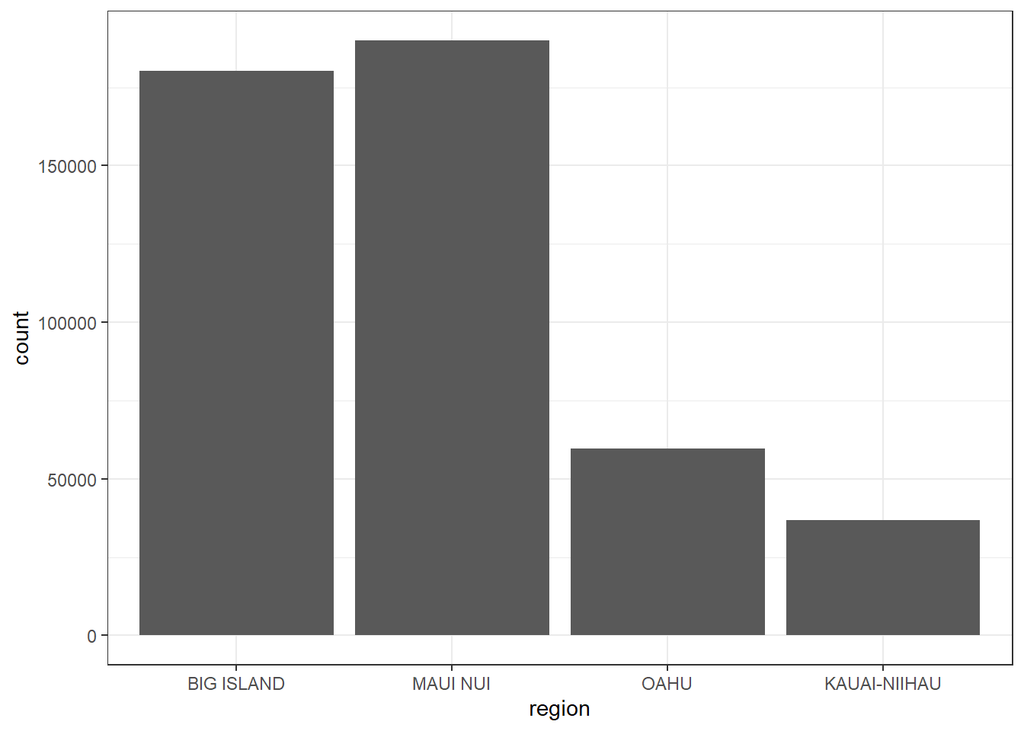

```
##   BIG ISLAND     MAUI NUI         OAHU KAUAI-NIIHAU
##       180131       189923        59549        36890
```

# More detailed analyses by species

# Opakapaka

Catch through time

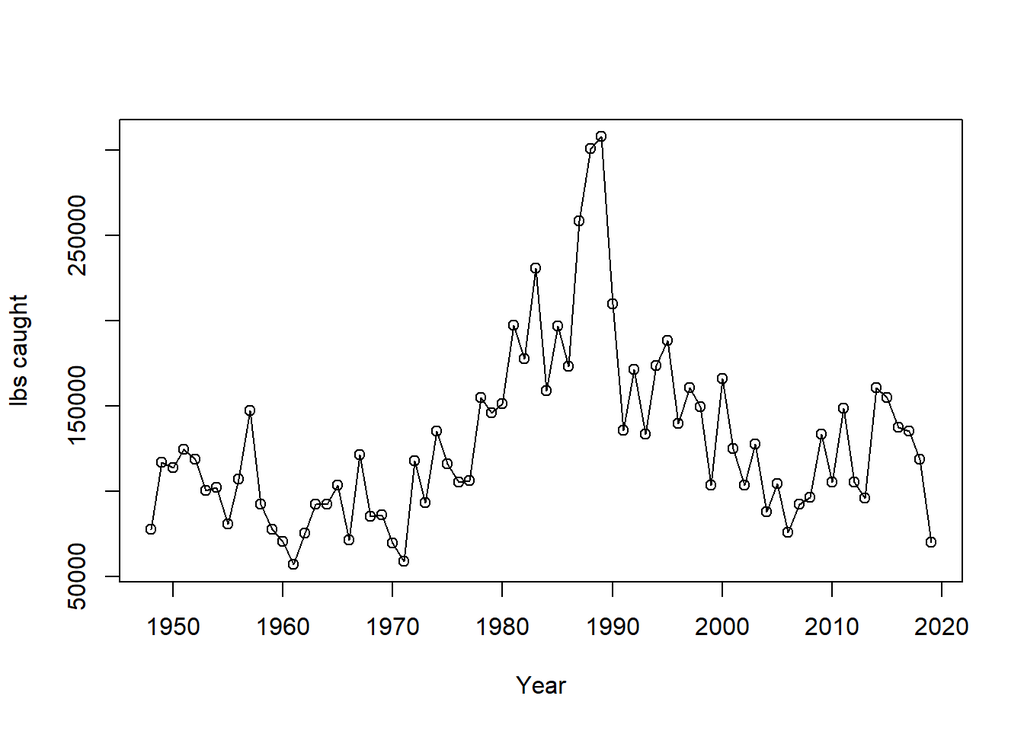

Number of catch records by year

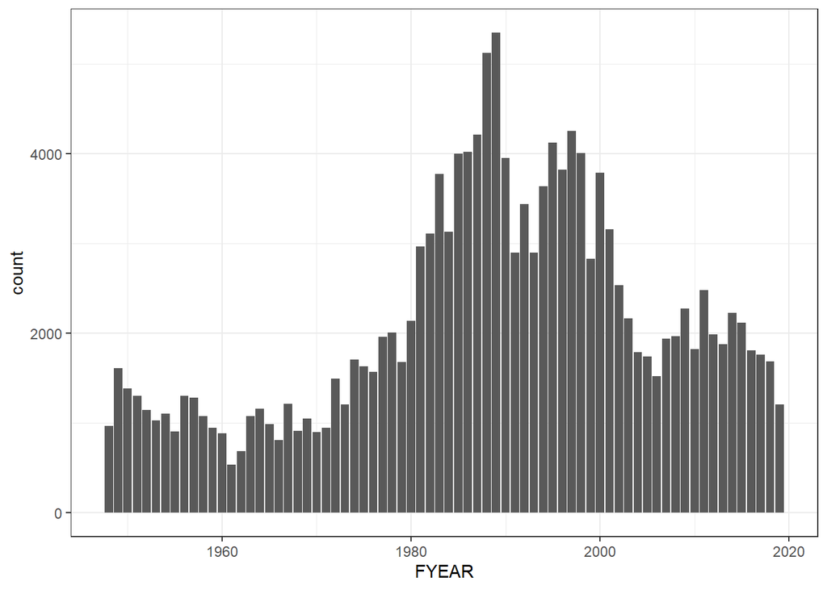

```
##    Min. 1st Qu.  Median    Mean 3rd Qu.    Max.
##    1948    1980    1990    1989    2000    2019
```

Catch by calendar month (monthly mean among calendar years)

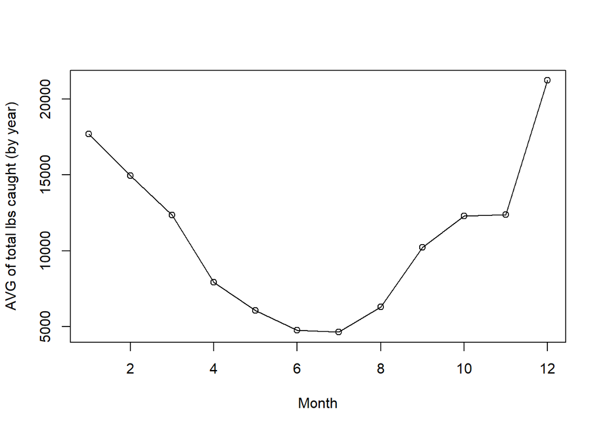

Number of catch records by region (years pooled)

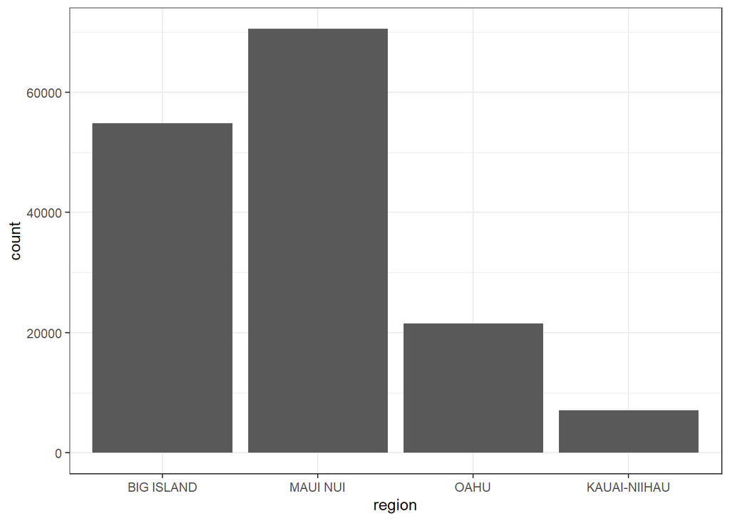

```
##   BIG ISLAND     MAUI NUI         OAHU KAUAI-NIIHAU
##        54856        70527        21519         7093
```

Proportion of paka catch (in lbs) by island region through time

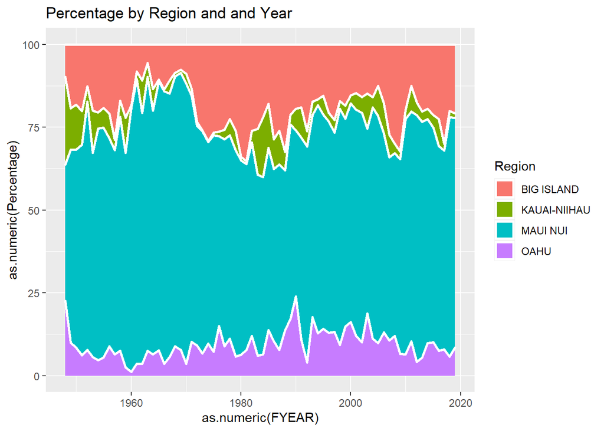

Look at catch by HDAR reporting area

Proportion of records in top 10 and 20 areas, respectively (years pooled).

```
## [1] 0.6043611
```

```
## [1] 0.7410541
```

Top 10 areas ("Group.1")

```
##    Group.1         x
## 62     320 1408432.3
## 71     331 1357515.2
## 69     327  639883.9
## 12     122  606075.5
## 63     321  446671.4
## 70     328  344534.5
## 11     121  277850.5
## 66     324  193691.6
## 67     325  170544.4
## 65     323  164194.1
```

Maps of catch by HDAR reporting area (total and decade)

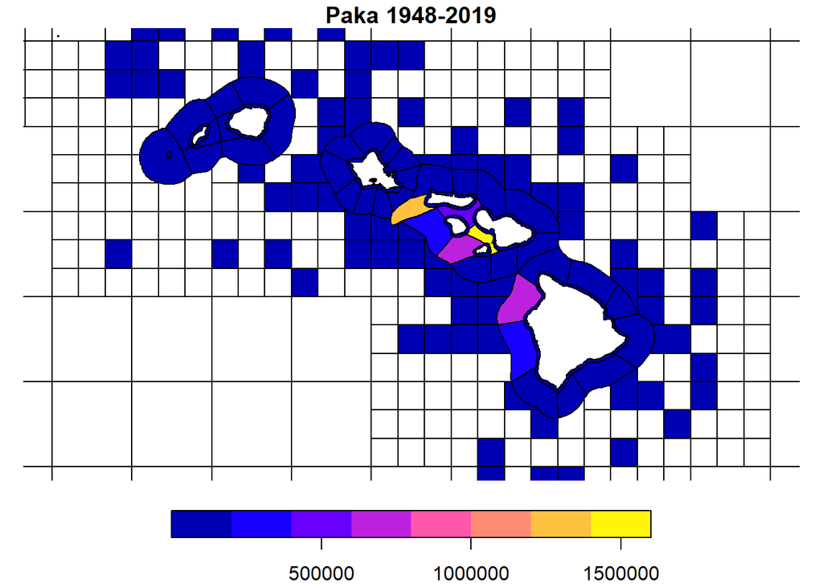

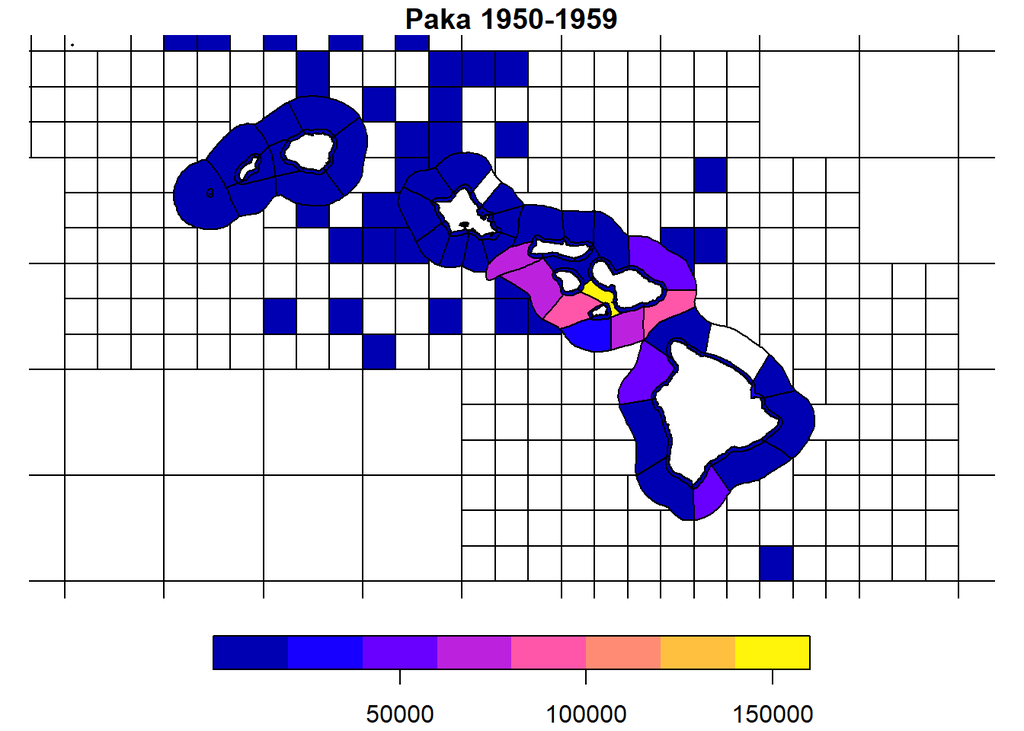

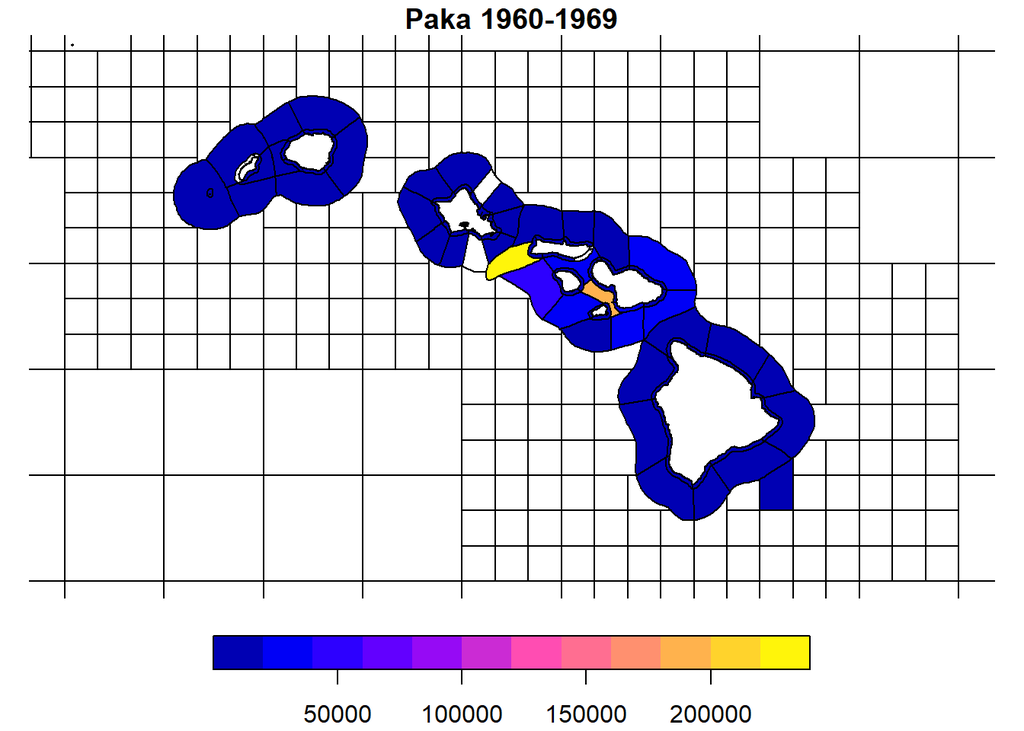

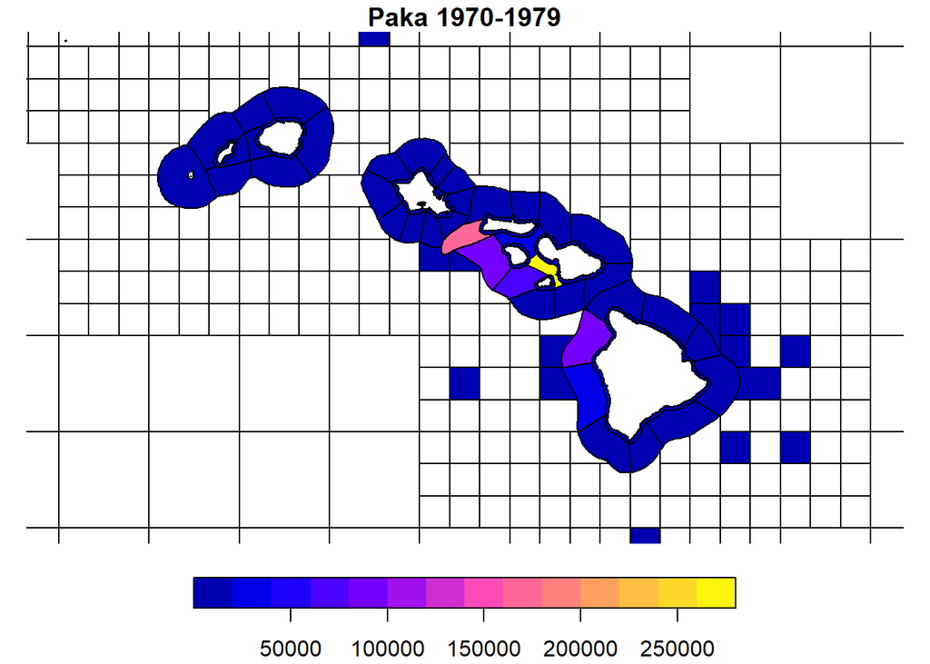

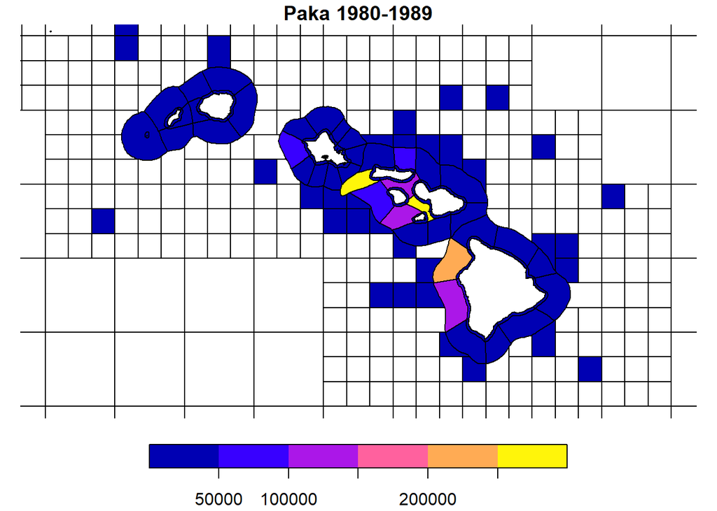

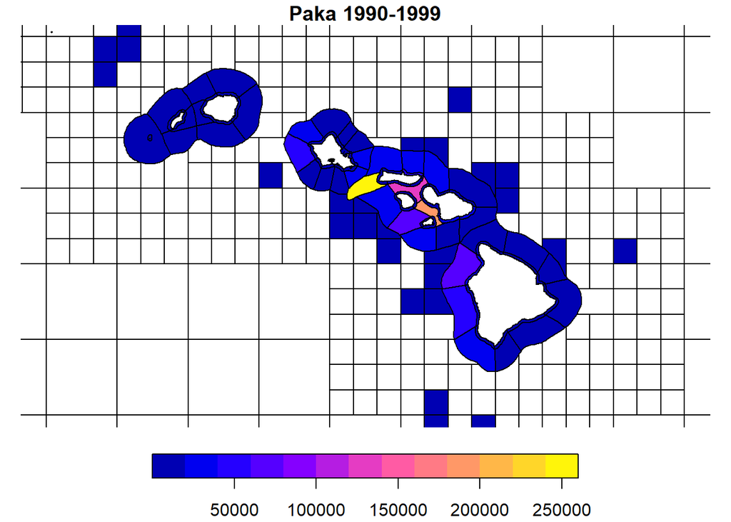

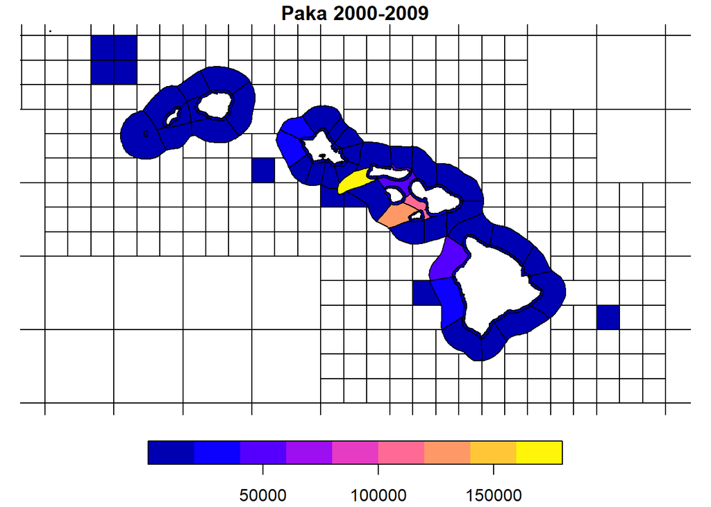

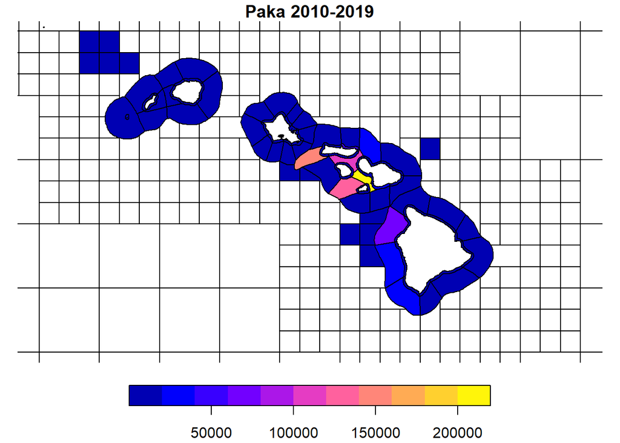

Catch by gear

Proportion of catch (lbs) and records, respectively, on deep-sea handline

```
## [1] 0.9705675
```

```
## [1] 0.9488165
```

Catch by gear through time

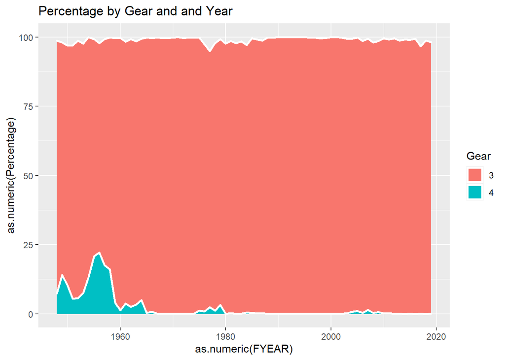

# Onaga

Catch through time

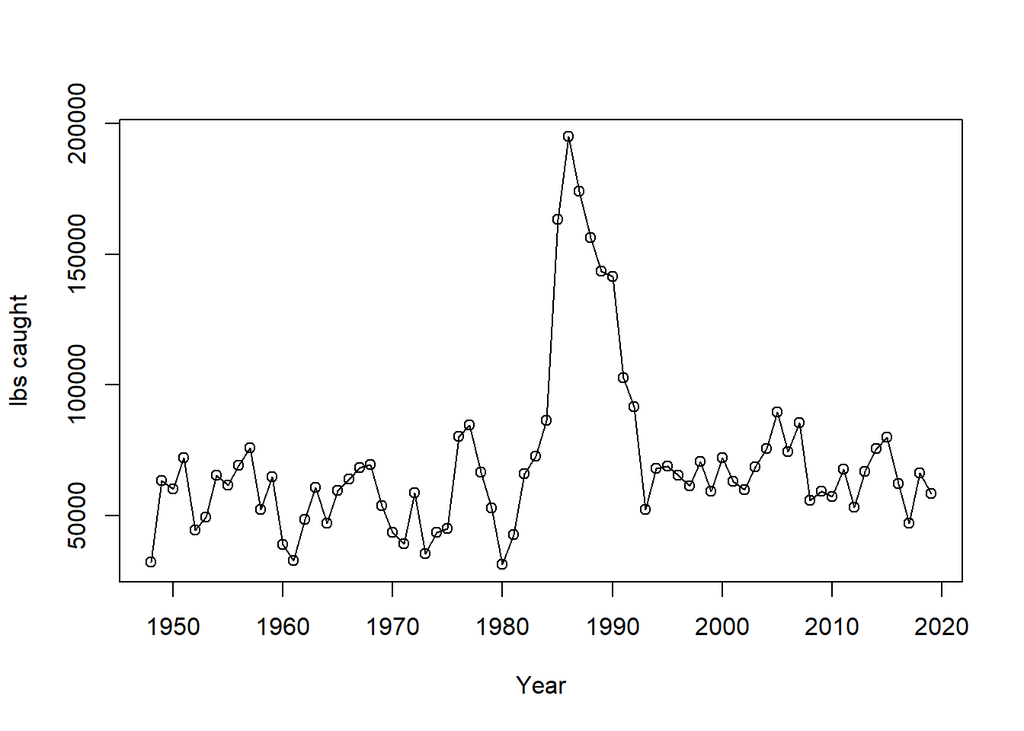

Number of catch records by year

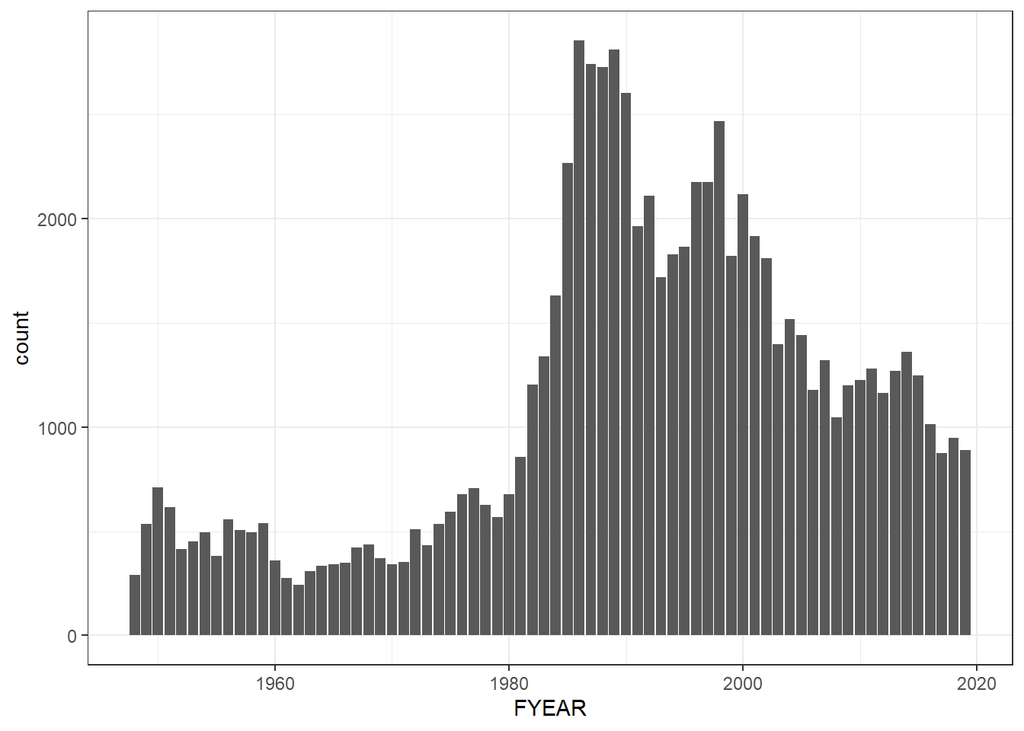

```
##    Min. 1st Qu.  Median    Mean 3rd Qu.    Max.
##    1948    1984    1992    1991    2003    2019
```

Catch by calendar month (monthly mean among calendar years)

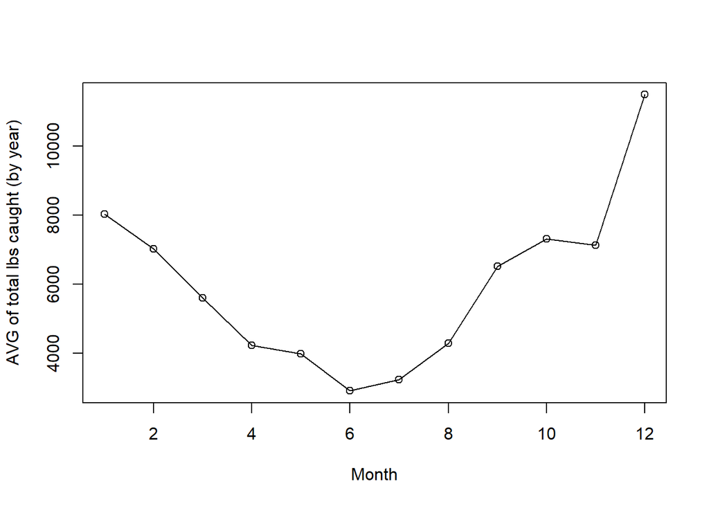

Number of catch records by region (years pooled)

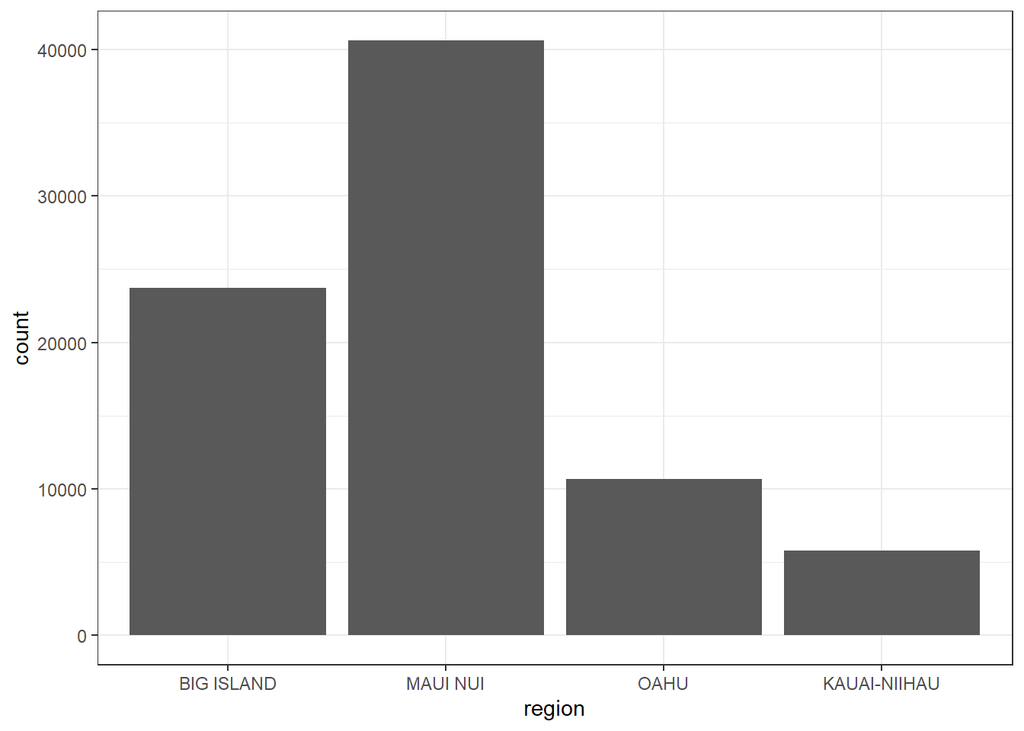

```
##   BIG ISLAND     MAUI NUI         OAHU KAUAI-NIIHAU
##        23721        40610        10698         5783
```

Proportion of onaga catch (in lbs) by island region through time

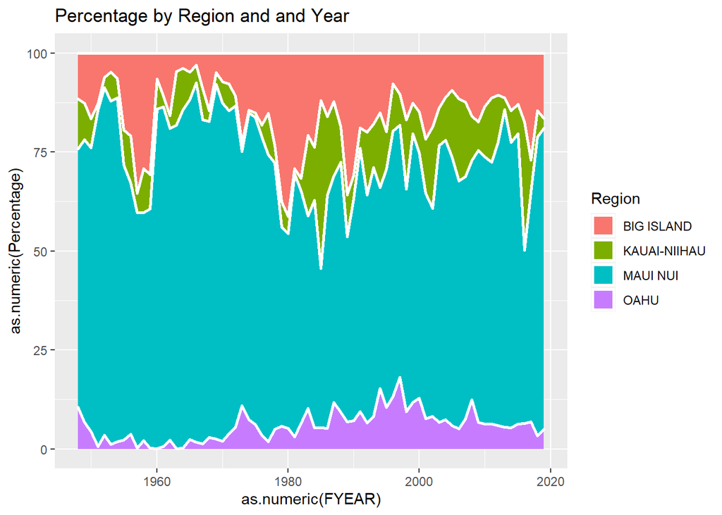

Look at catch by HDAR reporting area

Proportion of records in top 10 and 20 areas, respectively (years pooled).

```
## [1] 0.621472
```

```
## [1] 0.7609179
```

Top 10 areas ("Group.1")

```
##    Group.1        x
## 59     328 803490.9
## 60     331 796274.2
## 51     320 339798.2
## 52     321 269623.8
## 58     327 231021.0
## 56     325 222924.0
## 12     122 194597.7
## 55     324  99348.2
## 41     305  96779.9
## 54     323  90320.8
```

Maps of catch by HDAR reporting area (total and decade)

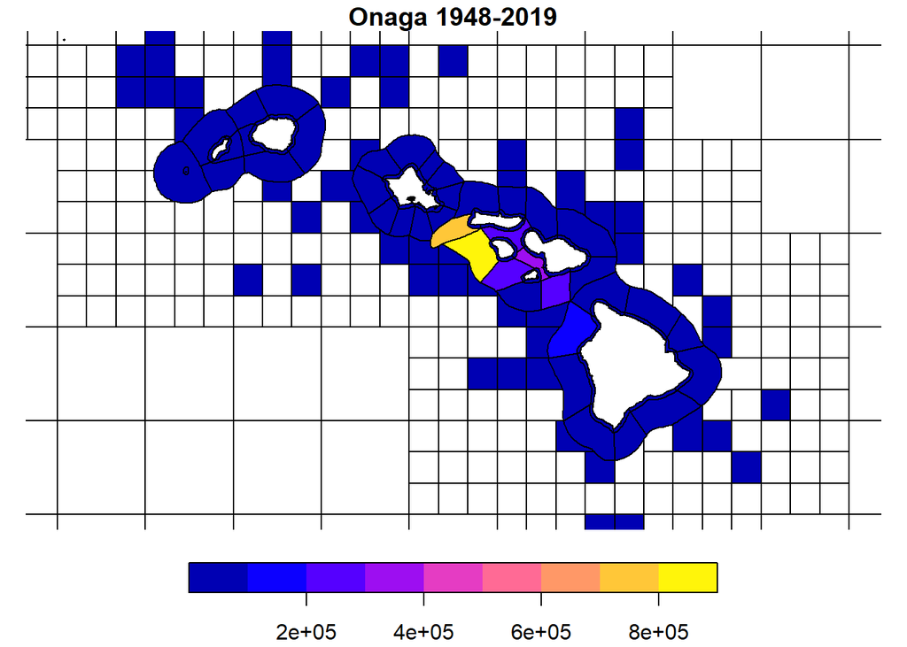

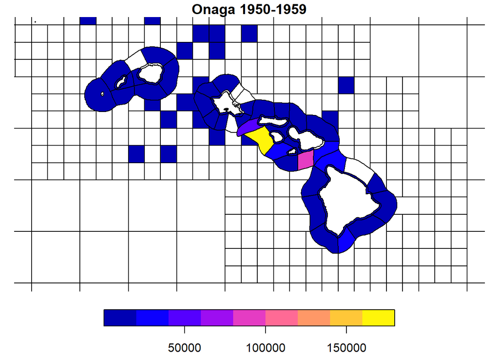

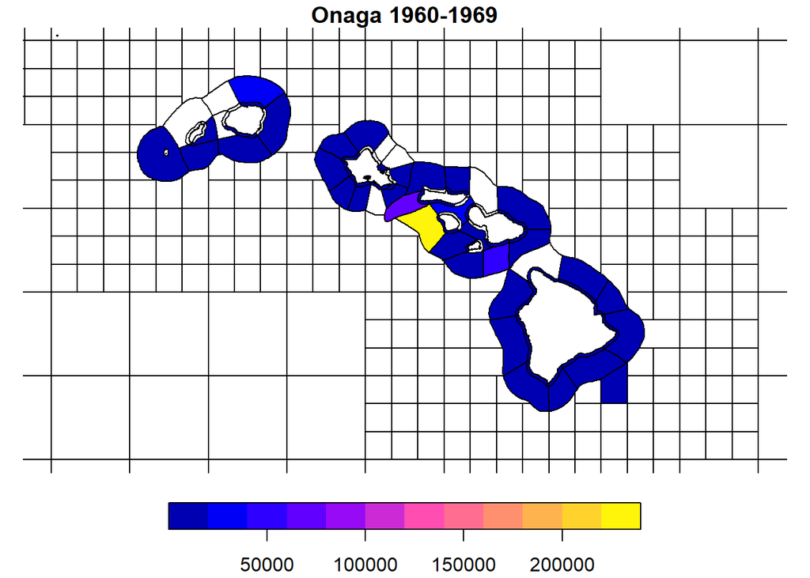

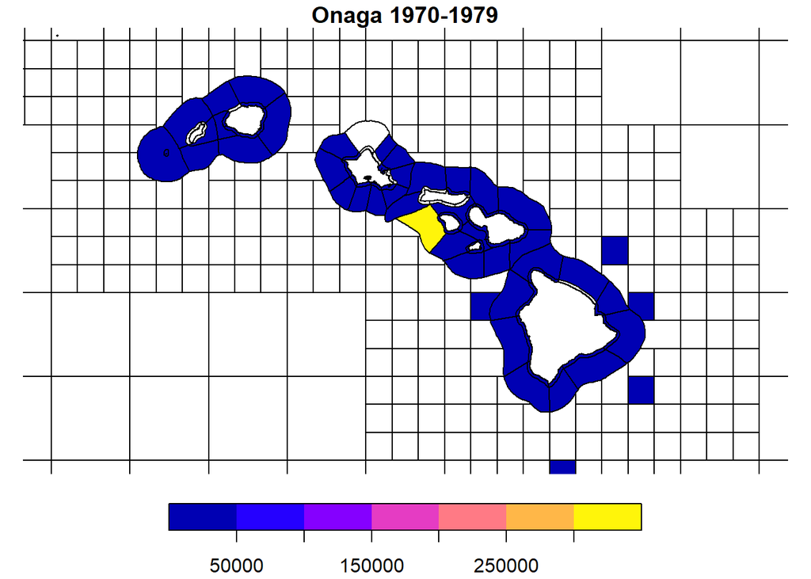

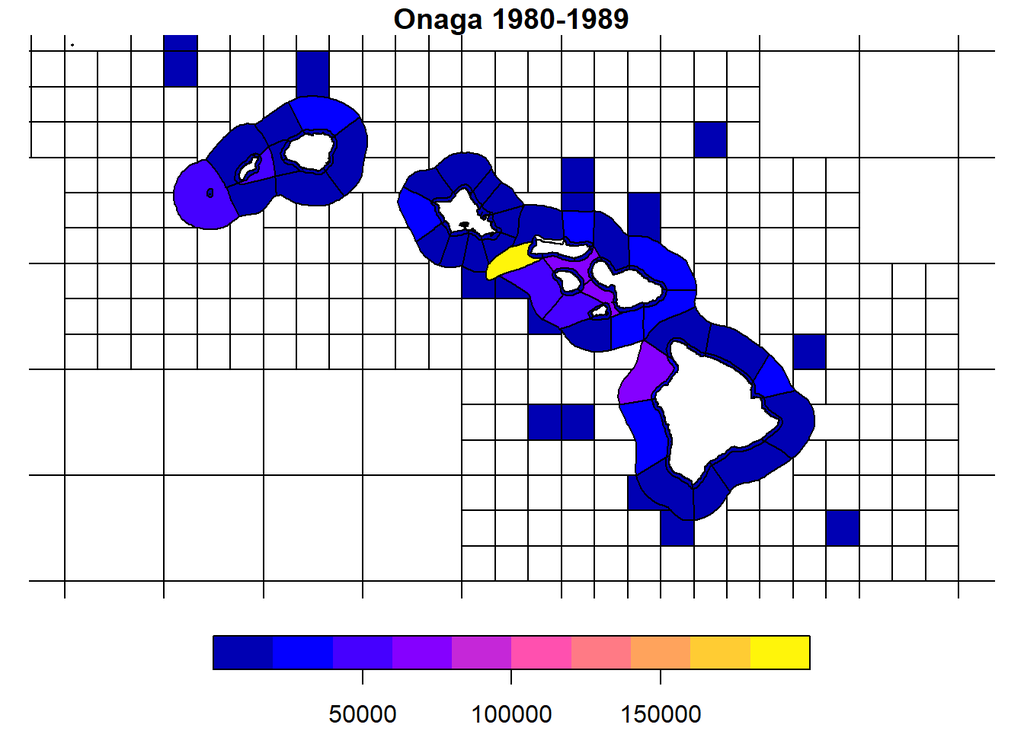

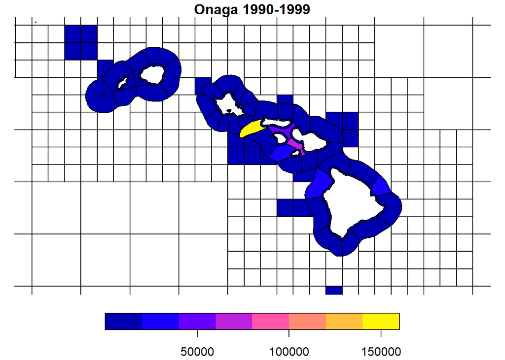

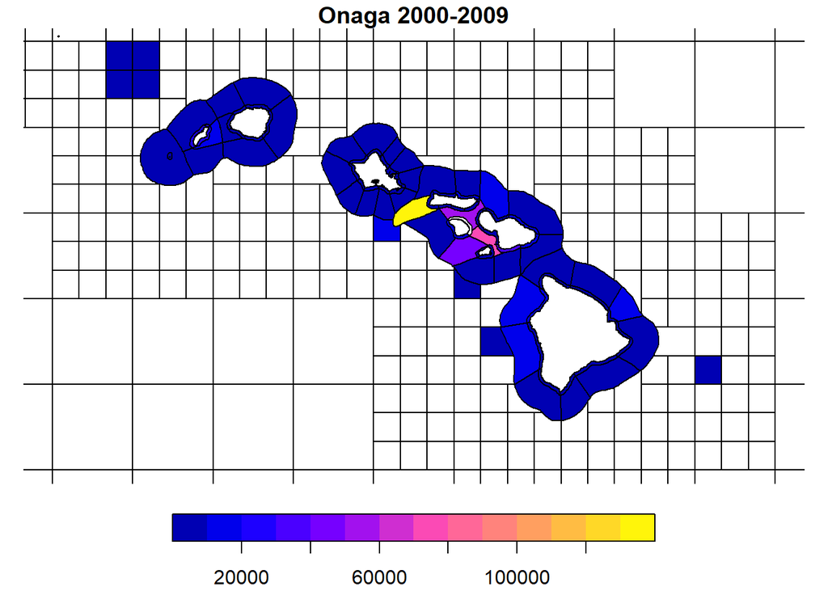

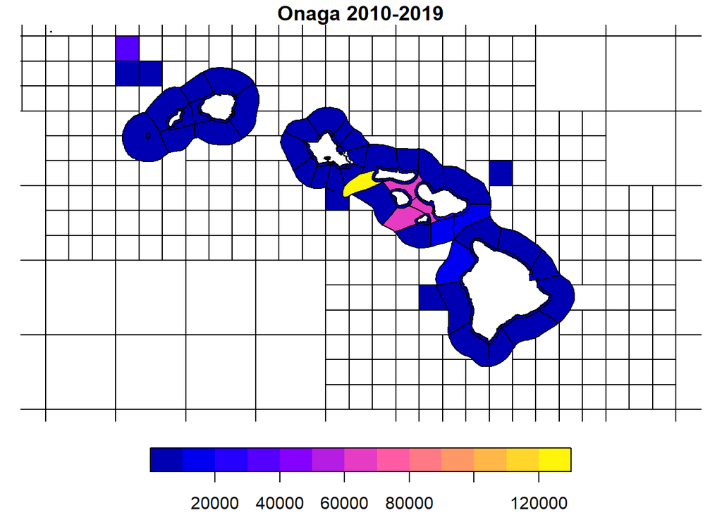

Catch by gear

Proportion of catch (lbs) and records, respectively, on deep-sea handline

```
## [1] 0.9897398
```

```
## [1] 0.9811538
```

Catch by gear through time

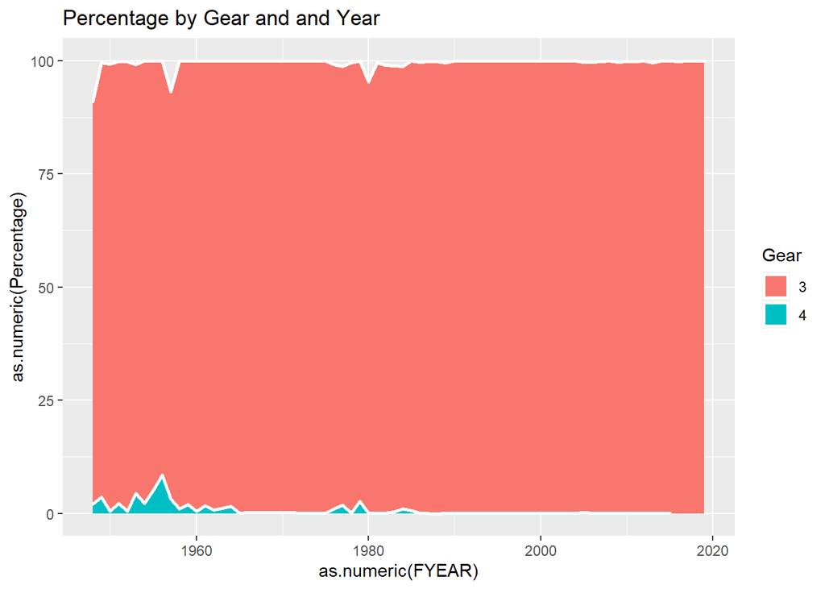